# Series temporales y Apple

Iker Aguirre Otaegui

11/16/2020

El siguiente trabajo tiene como objetivo realizar una predicción sobre las ventas para los años 2017 y 2018 de la multinacional americana Apple. Para ello, nos serviremos de la información de las ventas de la compañía en la última década. Utilizaremos el modelo ETS y ARIMA que mejor predicción realicen.

Cargamos la base de datos con la información.

```r
apple <- read.csv("IngresosApple.csv",
                  sep=";")
apple
```

```
##    Trimestre Ingresos
## 1    Q2 2008     7980
## 2    Q3 2008     7561
## 3    Q4 2008    11520
## 4    Q1 2009    11880
## 5    Q2 2009     9084
## 6    Q3 2009     9734
## 7    Q4 2009    12207
## 8    Q1 2010    15683
## 9    Q2 2010    13499
## 10   Q3 2010    15700
## 11   Q4 2010    20343
## 12   Q1 2011    26741
## 13   Q2 2011    24667
## 14   Q3 2011    28571
```

[output cut: 24 more lines]

Como se puede observar, los datos abarcan desde el segundo trimestre de 2008 hasta el tercero de 2017.

```r
str(apple)
```

```
## 'data.frame':    38 obs. of  2 variables:
##  $ Trimestre: chr  "Q2 2008" "Q3 2008" "Q4 2008" "Q1 2009" ...
##  $ Ingresos : int  7980 7561 11520 11880 9084 9734 12207 15683 13499 15700 ...
```

```r
skim(apple)
```

Data summary

| Name | apple |
| --- | --- |
| Number of rows | 38 |
| Number of columns | 2 |
| _______________________ |  |
| Column type frequency: |  |
| character | 1 |
| numeric | 1 |
| ________________________ |  |
| Group variables | None |

**Variable type: character**

| skim_variable | n_missing | complete_rate | min | max | empty | n_unique | whitespace |
| --- | --- | --- | --- | --- | --- | --- | --- |
| Trimestre | 0 | 1 | 7 | 7 | 0 | 38 | 0 |

**Variable type: numeric**

| skim_variable | n_missing | complete_rate | mean | sd | p0 | p25 | p50 | p75 | p100 | hist |
| --- | --- | --- | --- | --- | --- | --- | --- | --- | --- | --- |
| Ingresos | 0 | 1 | 36292.47 | 19632.6 | 7561 | 16860.75 | 37452 | 48916.75 | 78351 | ▇▃▇▃▂ |

Creamos una nueva variable “quarters” para poder convertir a xts. Después, convertimos los datos a una serie trimestral.

```r
quarters <- seq(as.Date("2008-04-01"),
                as.Date("2017-09-30"),
                by = "quarter")
apple_xts <- xts(apple$Ingresos, order.by = quarters)
apple_xts <- to.quarterly(apple_xts)
```

```r
apple_xts
```

```
##         apple_xts.Open apple_xts.High apple_xts.Low apple_xts.Close
## 2008 Q2           7980           7980          7980            7980
## 2008 Q3           7561           7561          7561            7561
## 2008 Q4          11520          11520         11520           11520
## 2009 Q1          11880          11880         11880           11880
## 2009 Q2           9084           9084          9084            9084
## 2009 Q3           9734           9734          9734            9734
## 2009 Q4          12207          12207         12207           12207
## 2010 Q1          15683          15683         15683           15683
## 2010 Q2          13499          13499         13499           13499
## 2010 Q3          15700          15700         15700           15700
## 2010 Q4          20343          20343         20343           20343
## 2011 Q1          26741          26741         26741           26741
## 2011 Q2          24667          24667         24667           24667
## 2011 Q3          28571          28571         28571           28571
```

[output cut: 24 more lines]

Ahora, transformamos los datos a zoo.

```r
apple_zoo <- as.zoo(apple_xts$apple_xts.Close)
```

Segmentamos la muestra en dos subgrupos:

1. El primero, la que al uso sería la muestra test, será la que vamos a intentar predecir (2017). No lo usaremos en esta ocasión.
2. El segundo incluirán todos los datos de ventas previos disponibles (2008 - 2016)

```r
length(apple_zoo)
```

```
## [1] 38
```

Puesto que sabemos que hay un total de 38 trimestres, y que solo tres pertenecen a la muestra de test, podemos separarlos de manera manual.

```r
apple_test <- apple_zoo[36:38]
apple_train <- apple_zoo[1:35]
```

Creamos un dataframe con los ingresos y los trimestres, que más adelante utilizaremos para la representación gráfica de las predicciones.

```r
df_apple <- data.frame(value = as.vector(apple_zoo),
                     time = time(apple_zoo))
```

# Modelo ETS

```r
ets_apple <- ets(apple_train)
summary(ets_apple)
```

```
## ETS(M,A,M)
##
## Call:
##  ets(y = apple_train)
##
##   Smoothing parameters:
##     alpha = 0.493
##     beta  = 0.493
##     gamma = 0.507
##
##   Initial states:
##     l = 7125.3462
##     b = 1485.7975
##     s = 1.1511 1.1163 0.8322 0.9004
##
##   sigma:  0.1222
##
##      AIC     AICc      BIC
## 703.9538 711.1538 717.9519
##
## Training set error measures:
##                   ME     RMSE      MAE       MPE     MAPE      MASE      ACF1
## Training set -41.934 4120.155 2883.262 -0.297759 8.677434 0.4160202 0.1438481
```

Como se puede observar, el modelo sigue la estructura M, A, M:

Representamos los residuos con el fin de que se asemeje lo máximo posible al ruido blanco:

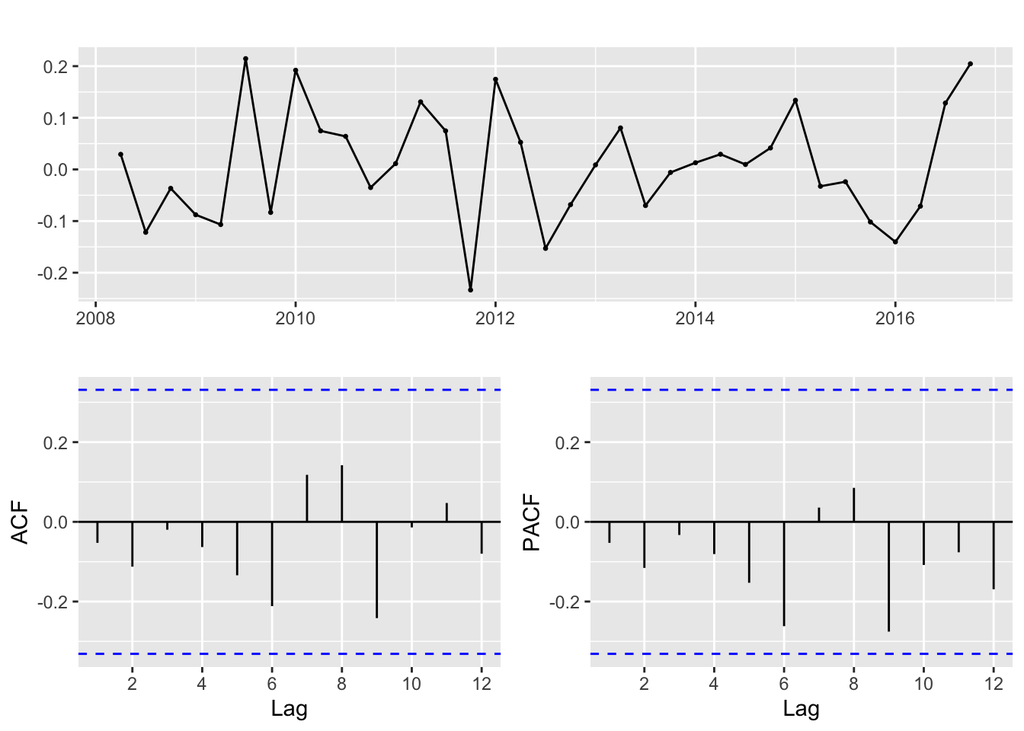

```r
ggtsdisplay(ets_apple$residuals)
```

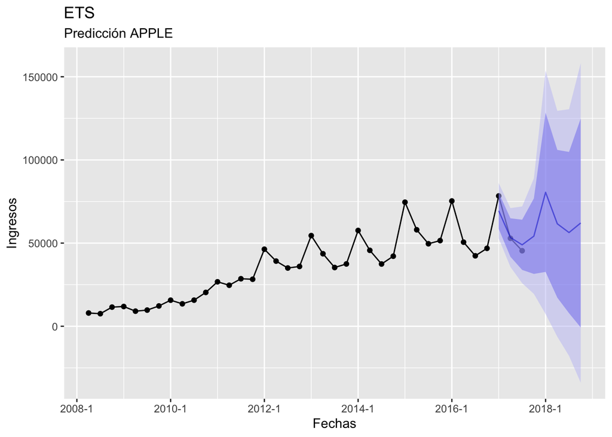

```r
prediccion_ets <- forecast(ets_apple)

ggplot(df_apple) + geom_point(aes(x = time, y = value)) +
  geom_line(aes(x = time, y = value)) + geom_forecast(prediccion_ets,
                                                  alpha = 0.5) +
      labs(title = "ETS", subtitle = "Predicción APPLE",
           x = "Fechas", y = "Ingresos")
```

# Modelo Arima

```r
arima_apple <- auto.arima(apple_train, lambda = 0)
summary(arima_apple)
```

```
## Series: apple_train
## ARIMA(0,1,0)(0,1,0)[4]
## Box Cox transformation: lambda= 0
##
## sigma^2 estimated as 0.01472:  log likelihood=20.72
## AIC=-39.45   AICc=-39.3   BIC=-38.04
##
## Training set error measures:
##                     ME     RMSE      MAE       MPE     MAPE      MASE      ACF1
## Training set -764.5058 4786.405 3054.054 -1.321616 8.284962 0.4406634 0.1269135
```

Al igual que con el modelo ETS, graficamos los residuos del modelo ARIMA con la intención de que se asemeje lo máximo posible al ruido blanco.

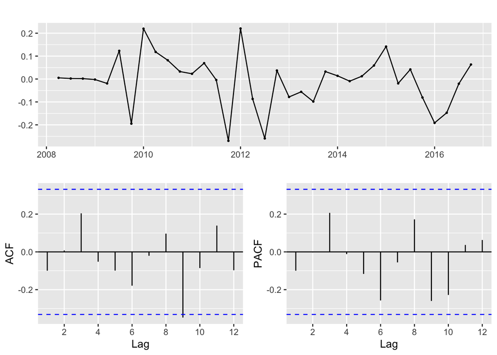

```r
ggtsdisplay(arima_apple$residuals)
```

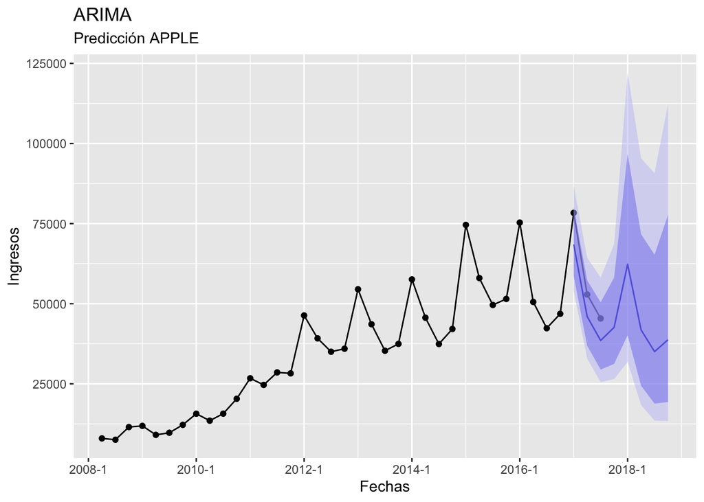

```r
prediccion_arima <- forecast(arima_apple)

ggplot(df_apple) + geom_point(aes(x = time, y = value)) +
  geom_line(aes(x = time, y = value)) + geom_forecast(prediccion_arima,
                                                  alpha = 0.5) +
      labs(title = "ARIMA", subtitle = "Predicción APPLE",
           x = "Fechas", y = "Ingresos")
```

# Comparación y elección de de modelos

```r
summary(ets_apple)
```

```
## ETS(M,A,M)
##
## Call:
##  ets(y = apple_train)
##
##   Smoothing parameters:
##     alpha = 0.493
##     beta  = 0.493
##     gamma = 0.507
##
##   Initial states:
##     l = 7125.3462
##     b = 1485.7975
##     s = 1.1511 1.1163 0.8322 0.9004
##
##   sigma:  0.1222
##
##      AIC     AICc      BIC
## 703.9538 711.1538 717.9519
##
## Training set error measures:
##                   ME     RMSE      MAE       MPE     MAPE      MASE      ACF1
## Training set -41.934 4120.155 2883.262 -0.297759 8.677434 0.4160202 0.1438481
```

```r
summary(arima_apple)
```

```
## Series: apple_train
## ARIMA(0,1,0)(0,1,0)[4]
## Box Cox transformation: lambda= 0
##
## sigma^2 estimated as 0.01472:  log likelihood=20.72
## AIC=-39.45   AICc=-39.3   BIC=-38.04
##
## Training set error measures:
##                     ME     RMSE      MAE       MPE     MAPE      MASE      ACF1
## Training set -764.5058 4786.405 3054.054 -1.321616 8.284962 0.4406634 0.1269135
```

En este caso escogeríamos el modelo ETS, puesto que dispone de menos RMSE. Su tendencia parece más alcista.